# Listen: Pop or Country, Hiphop or R&B

Huizhe (Sunny) ZHU

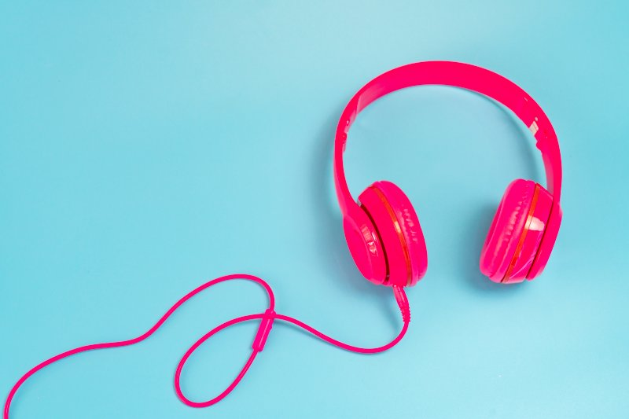

People on internet are arguing about the difference between Country and Pop songs, Hiphop and R&B songs. Pop represents ‘popular’, while country music is also popular in many regions including the U.S., which makes them very similar to each other. Meanwhile, Hip-Hop is considered as one of Rhythm & Blues (R&B)’s components, for this reason, it is also difficult to distinguish Hip-Hop and R&B music.

Given the ‘lyrics’ database that contains more than 120,000 songs, we here have the chance to discover the differences among these genres by real world examples. The lyrics dataset contains 7534 Country songs, 18697 Pop songs, 8905 Hip-Hops, and 2174 R&B songs.

#### 1. Compare lyrics length

According to the boxplot below, we can observe that Pop music tends to be longer and has a larger variance than country songs , while country music tends to be shorter and has a smaller variance.

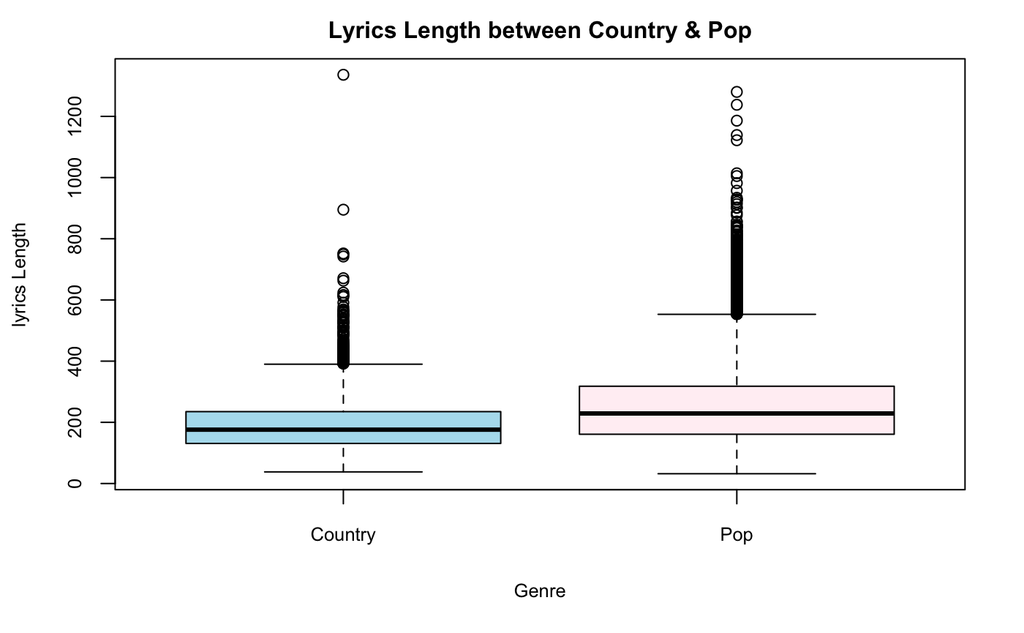

For Hip-Hop and R&B, the difference is more significant. We can see from the boxplot that on average, Hip-Hop music is longer and has a larger variance, while R&B tends to be shorter and has smaller variance.

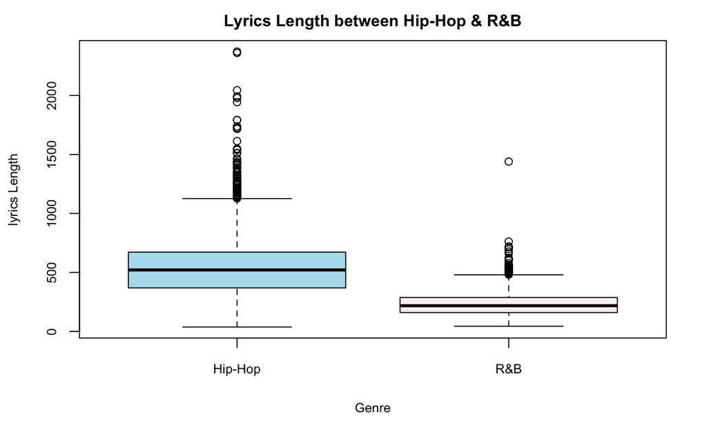

#### 2. Compare high-frequency words

Next, let’s analyze the high-frequency words from different genres and check if there is a difference.

#### 2.1 Pop and Country

*Note: The frequency on the y-axis is calculated by the word count/the number of songs from that genre;*

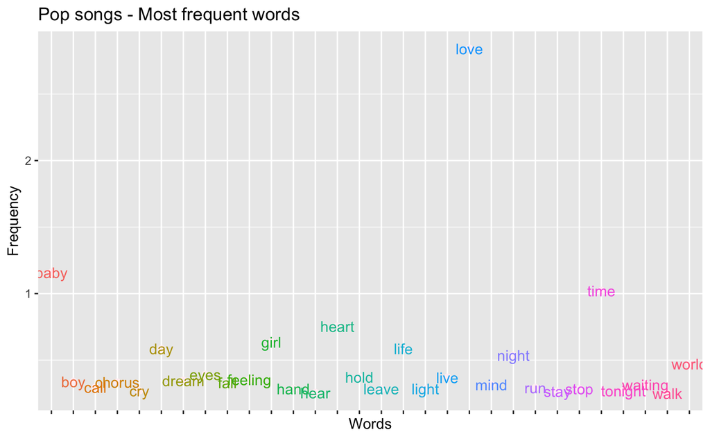

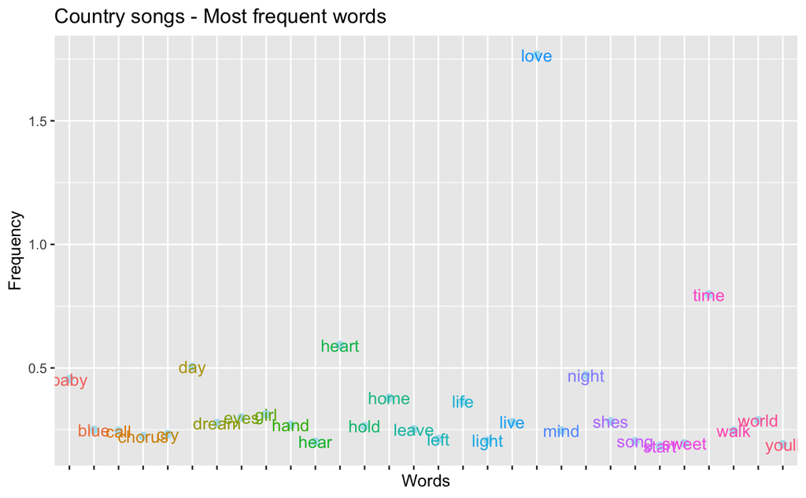

#### 2.2 HipHops and R&B

HipHops and R&B’s most frequent word is also ‘love’. In addition, they both include the same frequent words such as ‘baby’, ‘time’, ‘girl’ .. etc.

Other than that, as illustrated from the graph, we can observe that there is a distinguishable differene between Hip-Hops and R&B music. (1). Hip-Hops contains large amount of rude words, as shown in the graph. For the report purpose, some words are modified with ’*‘. (2). In addition, Hip-Hop music also contains words such as ’ya’, ‘yo’, ‘rock’… which are considered as typical Hip-Hops words. In this case, these words can be used to identify Hip-Hop music as well. (3). Hip-Hop contains more words such as ‘money’, ‘hit’, ‘game’ etc. compared to R&B. Regarding the high-frequency words in R&B music, we can conclude that R&D is more similar to Pop and Country music compare to Hip-Hop.

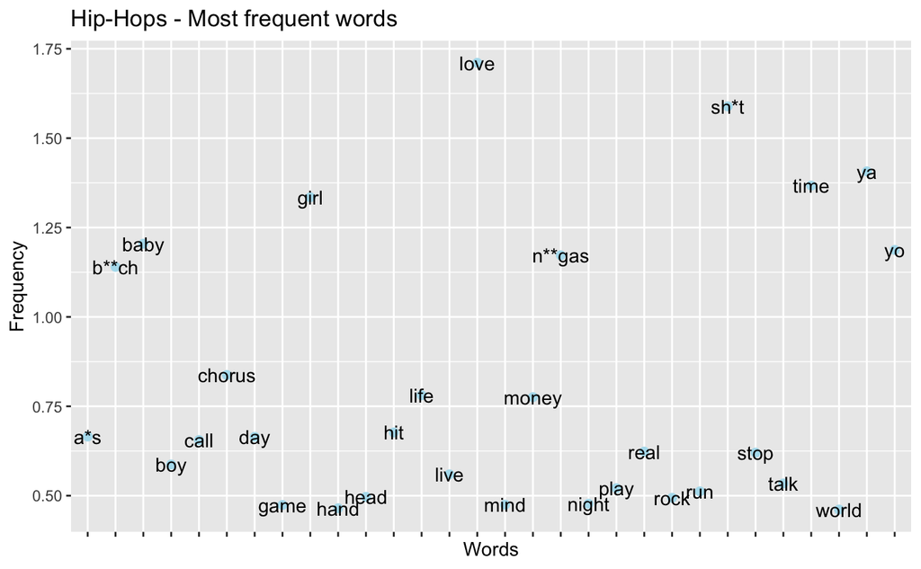

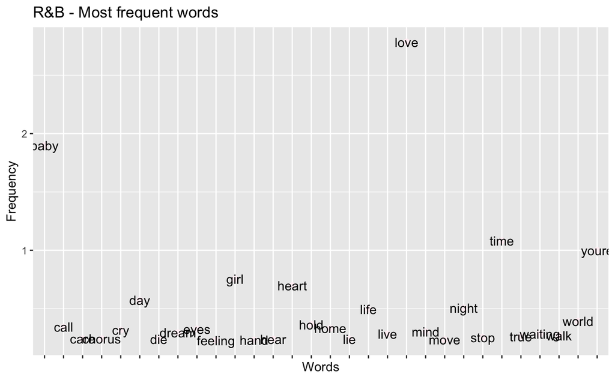

#### 3. Compare their emotions

Now let’s check the sentiment of these genres! We conduct sentiment analysis by comparing and illustrating the sentiment scores for these 4 different types of genres. As shown in the graph, regarding emotions, Hip-Hop and R&B are more similar, as they contain stronger emotions. However, Hip-Hop tends to have more negative emotion and R&B music tends to have more positive emotion. For Country and Pop music, they are more similar to each other, as their emotions are more gentle, and both of they contain more balanced emotions.

#### Sentiment for each genre

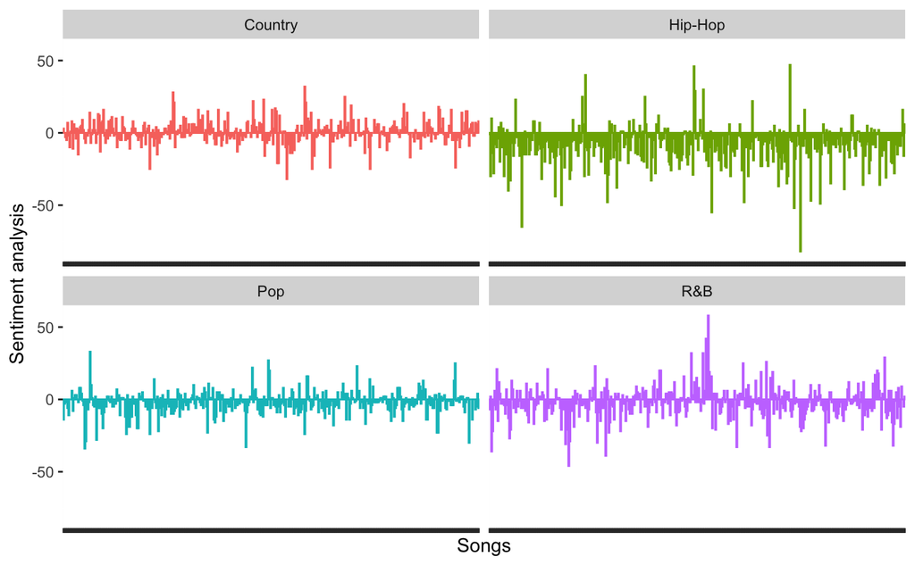

#### Summary

**Lyrics length:** Pop music tends to be longer and has a larger variance compared to Country music. For Hip-Hop and R&B, we can see that on average, Hip-Hop tends to be longer than R&B and has a larger variance, while R&B tends to be shorter and has smaller variance.

**Emotion variation:** Comparing the sentiment score for these 4 different types of songs, we can conclude that Hip-Hop and R&B music tend to have stronger emotion, while country and pop are more gentle. Hip-hop tends to have more negative words that R&B, and Country and Pop music are more similar to each other as they both contains balanced emotions.

**In conclusion**, there is significant difference between Pop and Country music in lyrics length, but their frequent words and emotion variation are quite similar. For Hip-Hop and R&B, they can be distinguished by all three factors discussed above: R&B tends to be shorter, more similar to Pop/Country songs regarding frequent words, and has relatively more positive emotion compared to Hip-Hop.

#### References

Quora (2019) from https://www.quora.com/How-do-you-differentiate-between-a-country-song-and-a-pop-song-just-by-listening-to-it

Silge, J., & Robinson, D. (2019, November 24). Text Mining with R. Retrieved January 27, 2020, from https://www.tidytextmining.com/sentiment.htmlhttps://www.tidytextmining.com/sentiment.html